# Homework 2

Tara Ahi

02/05/2022

## Question 0

Add your name and the date to the R Markdown Header.

Insert a floating table of contents to the HTML.

## Question 1

This data was collected from www.theramenrater.com. It provides information on different reviews of ramen products, and has variables: Review #, Brand, Variety, Style, Country, Stars, and Top Ten.

#### (a)

Read in the Ramen data and check it carefully.

```r
ramen_df <- read_csv("data/ramen-ratings.csv")
```

#### (b)

Rename the first variable to be “review_number”, and the last variable to be “top_ten”. Additionally, ensure that the Stars column is saved as a numeric variable, and remove any non-numeric entries.

```r
renamed_ramen <- ramen_df %>%
  rename(review_number = `Review #`) %>%
  rename(top_ten = `Top Ten`)
#renamed columns

summary(renamed_ramen)
```

```
##  review_number       Brand             Variety             Style
##  Min.   :   1.0   Length:2580        Length:2580        Length:2580
##  1st Qu.: 645.8   Class :character   Class :character   Class :character
##  Median :1290.5   Mode  :character   Mode  :character   Mode  :character
##  Mean   :1290.5
##  3rd Qu.:1935.2
##  Max.   :2580.0
##    Country             Stars             top_ten
##  Length:2580        Length:2580        Length:2580
##  Class :character   Class :character   Class :character
##  Mode  :character   Mode  :character   Mode  :character
##
##
##
```

```r
#checking to see which class each variable is

renamed_ramen$Stars <- as.numeric(renamed_ramen$Stars)
#made it numeric

renamed_ramen = renamed_ramen[!is.na(renamed_ramen$Stars), ]
#removed NA values
```

#### (c)

Filtering just for the the ‘Nissin’ ramen brand, calculate the average rating for each country of this brand. What country has the highest rating of Nissin ramen? What country has the lowest rating?

```r
nissin = renamed_ramen %>%
  filter(Brand == "Nissin")

nissin %>%
  group_by(Country) %>%
  summarize(mean_rating = mean(Stars, na.rm = TRUE))
```

```
## # A tibble: 14 × 2
##    Country     mean_rating
##    <chr>             <dbl>
##  1 Brazil             4.35
##  2 China              3.83
##  3 Colombia           3.29
##  4 Germany            3.69
##  5 Hong Kong          4.14
##  6 Hungary            3.75
##  7 India              3.25
##  8 Indonesia          3.88
##  9 Japan              4.26
## 10 Mexico             3.78
## 11 Philippines        2
## 12 Singapore          4.09
## 13 Thailand           3.81
## 14 USA                3.50
```

The country with the highest rating of Nissin ramen is **Brazil** with 4.35 stars. The country with the lowest rating of Nissin ramen is the **Philippines** with 2 stars.

#### (d)

Create a new variable called “popular” which returns a 1 for entries that have a rating above or equal to 4.5 stars, and 0 for those that don’t.

```r
updated_ramen = renamed_ramen %>%
  mutate(popular = case_when(Stars >= 4.5 ~ 1,
                             Stars < 4.5 ~ 0,
                             TRUE ~ 99))
```

#### (e)

Calculate the average stars for popular and not popular bowl ramen. Explain why (or why not) your results are meaningful.

```r
updated_ramen %>%
  group_by(popular) %>%
  summarize(mean_stars = mean(Stars, na.rm = TRUE))
```

```
## # A tibble: 2 × 2
##   popular mean_stars
##     <dbl>      <dbl>
## 1       0       3.30
## 2       1       4.86
```

The average stars for popular ramen is **4.86**. The average stars for not popular ramen is **3.3**.

There are a few reasons why they may not be meaningful: mean is not always the best indicator due to outliers, and there may be some bias in the types of people who provide ratings. More importantly, we had already split the dataset by popularity, so the average ratings won’t be as meaningful.

## Question 2

#### (a)

Read in NYC Airbnb data `AB_NYC_2019.csv`, and select only the: host_name, neighborhood_group, room_type, price, minimum_nights, and number_of_reviews. Note, the neighborhood_group variable refers to borough.

```r
airbnb_df <- read_csv("data/AB_NYC_2019.csv")
#read in

airbnb_select = airbnb_df %>%
  select(host_name, neighbourhood_group, room_type, price, minimum_nights, number_of_reviews)
#select variables
```

#### (b)

Create a new variable called minimum_price, which combines the minimum nights and price (per night) to give the minimum amount someone could pay to stay at the Airbnb.

```r
updated_airbnb = airbnb_select %>%
  mutate(minimum_price = minimum_nights*price)
```

#### (c)

Calculate the mean and median minimum_price using ‘summarize’. From these results, estimate whether you expect the data to be left or right skewed? Confirm your hypothesis by creating a histogram. Note, to improve the visualization of your histogram, consider removing very high prices.

```r
updated_airbnb %>%
  summary(minimum_price)
```

```
##   host_name         neighbourhood_group  room_type             price
##  Length:48895       Length:48895        Length:48895       Min.   :    0.0
##  Class :character   Class :character    Class :character   1st Qu.:   69.0
##  Mode  :character   Mode  :character    Mode  :character   Median :  106.0
##                                                            Mean   :  152.7
##                                                            3rd Qu.:  175.0
##                                                            Max.   :10000.0
##  minimum_nights    number_of_reviews minimum_price
##  Min.   :   1.00   Min.   :  0.00    Min.   :      0.0
##  1st Qu.:   1.00   1st Qu.:  1.00    1st Qu.:    135.0
##  Median :   3.00   Median :  5.00    Median :    300.0
##  Mean   :   7.03   Mean   : 23.27    Mean   :   1284.4
##  3rd Qu.:   5.00   3rd Qu.: 24.00    3rd Qu.:    734.5
##  Max.   :1250.00   Max.   :629.00    Max.   :1170000.0
```

The mean minimum price is **$1,284.40.** The median minimum price is **$300.00**. I estimate that the data is right-skewed, as the mean is much larger than the median.

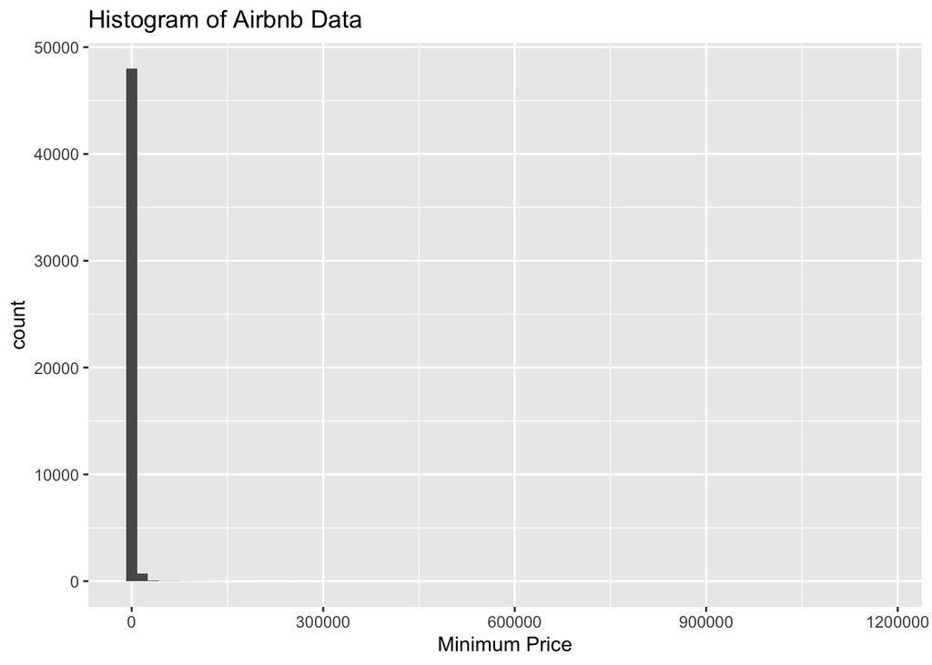

```r
ggplot(data = updated_airbnb) +
  geom_histogram(aes(x = minimum_price), bins = 70) +
  labs(title = "Histogram of Airbnb Data", x = "Minimum Price")
```

```r
#ugly graph
```

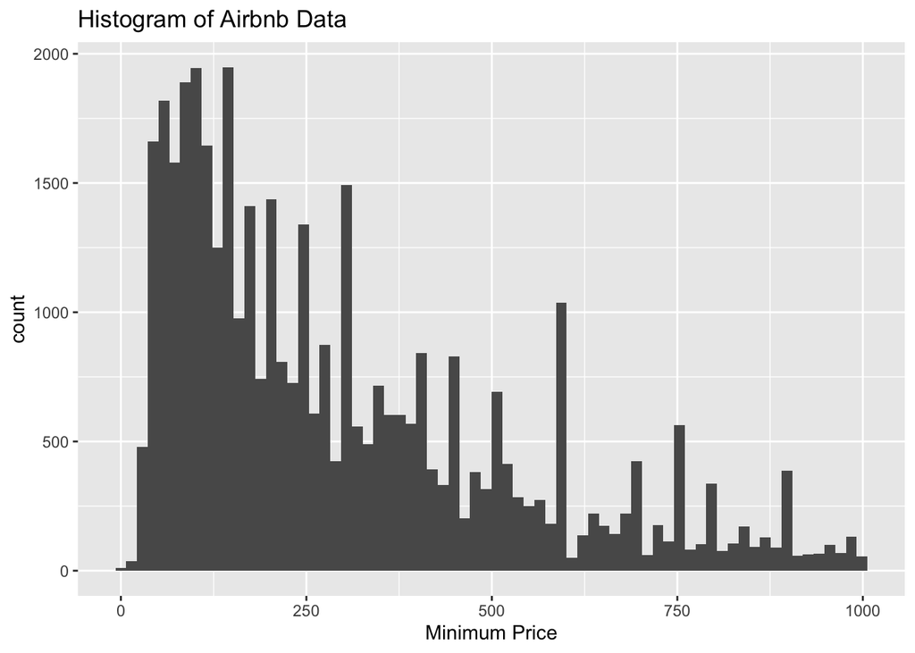

```r
narrowed_airbnb = subset(updated_airbnb, minimum_price < 1000)
#removing minimum prices over $1000

ggplot(data = narrowed_airbnb) +
  geom_histogram(aes(x = minimum_price), bins = 70) +
  labs(title = "Histogram of Airbnb Data", x = "Minimum Price")
```

**This graph is right-skewed, supporting my hypothesis.**

#### (d)

Are all of the New York City boroughs represented in the data? Prove your conclusion using the summarize function to show the number of observations in each borough.

```r
updated_airbnb %>%
  group_by(neighbourhood_group) %>%
  summarise(Count = n())
```

```
## # A tibble: 5 × 2
##   neighbourhood_group Count
##   <chr>               <int>
## 1 Bronx                1091
## 2 Brooklyn            20104
## 3 Manhattan           21661
## 4 Queens               5666
## 5 Staten Island         373
```

All five boroughs are represented. However, there are *many* more listings in the boroughs of Brooklyn and Manhattan compared to those in the Bronx, Queens and Staten Island, so it’s not exactly equal representation.

#### (e)

Plot a boxplot of price across boroughs, showing only properties less than 1,000 a night. From the graph, which borough appears to have the highest median price? Which seems to have the lowest median price? Confirm this result using summarize and report the median price by borough.

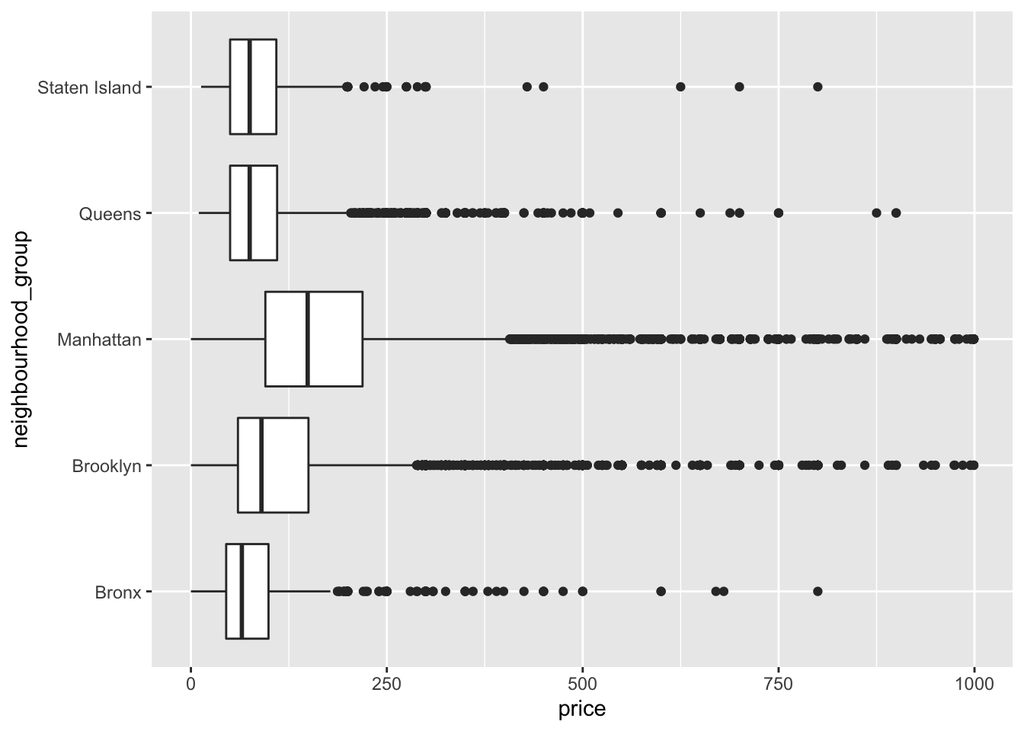

```r
cheaper_airbnb = subset(updated_airbnb, price < 1000)
#showing only peoperties less than $1000/night

ggplot(data = cheaper_airbnb) +
  geom_boxplot(aes(x = price, y = neighbourhood_group))
```

```r
#plot

cheaper_airbnb %>%
  group_by(neighbourhood_group) %>%
  summarize(median_price = median(price, na.rm = TRUE))
```

```
## # A tibble: 5 × 2
##   neighbourhood_group median_price
##   <chr>                      <dbl>
## 1 Bronx                         65
## 2 Brooklyn                      90
## 3 Manhattan                    149
## 4 Queens                        75
## 5 Staten Island                 75
```

```r
#confirm median results
```

**Manhattan** has the highest median price at $149. **The Bronx** has the lowest median price at $65. Brooklyn’s median price is $90. Queens and Staten Island both have a median price of $75.

#### (f)

What is the most commonly occurring host name? Re-write the code below using pipes and then report the answer in a sentence.

```r
#arrange(summarise(group_by(nyc_airbnb, host_name), n = n()), -n)

airbnb_df %>%
  group_by(host_name) %>%
  summarize(n = n()) %>%
  arrange(desc(n))
```

```
## # A tibble: 11,453 × 2
##    host_name        n
##    <chr>        <int>
##  1 Michael        417
##  2 David          403
##  3 Sonder (NYC)   327
##  4 John           294
##  5 Alex           279
##  6 Blueground     232
##  7 Sarah          227
##  8 Daniel         226
##  9 Jessica        205
## 10 Maria          204
## # … with 11,443 more rows
```

The most commonly-occurring host name is **Michael**.

## Question 3

#### (a)

You have been given a dataset for a study of a potential depression drug: `STUDYDAT12014.csv`. It includes treatment and placebo status, dose, age, along with HAM-D and HAM-A scores at baseline (`baseline_hamd` and `baseline_hama`) and at the end of the study (`outcome_hamd` and `outcome_hama`). Read in this dataset (`STUDYDAT12014.csv`) and report how many variables and how many observations are in this dataset.

```r
study_df <- read_csv("data/STUDYDAT12014.csv")
#read in
```

There are **200** observations and **8** variables in the dataset.

#### (b)

The investigators are interested in analyzing subjects who are at least 30 years old but less than 40 years old, so create a dataset which contains only observations from people within this age range. Use this dataset for all subsequent analyses.

```r
select_study <- filter(study_df, age >= 30 & age < 40)
```

#### (c)

The treatment groups are currently labeled `pbo` and `trx`, but the researchers would like to have them labeled `Placebo` and `Drug 13XA`. Please make these changes to the dataset you created in (b)

```r
select_study$trx[select_study$trx == "pbo"] <- "Placebo"
select_study$trx[select_study$trx == "trx"] <- "Drug 13XA"
```

#### (d)

Create two new variables `hamd_diff` and `hama_diff` that are changes between baseline and outcome measurements for HAM-A and HAM-D.

```r
updated_study = select_study %>%
  mutate(
    hamd_diff = baseline_hamd - outcome_hamd,
    hama_diff = baseline_hama - outcome_hama
  )
```

#### (e)

The investigators are interested in assessing whether there is a difference in (1) mean HAM-A changes between treatment groups and (2) mean HAM-D changes between treatment groups. Use t-tests (unequal variance) to test the difference between treatment groups for both of these outcomes. Be sure to report the test statistic, p-value, and degrees of freedom for each test in your write-up.

```r
updated_study = updated_study %>%
  mutate(
    mean_hamd_diff = mean(hamd_diff),
    mean_hama_diff = mean(hamd_diff)
  )
#create variables for mean changes - actually not necessary

hama_t_res = t.test(hama_diff ~ trx, data = updated_study,
                       var.equal = FALSE)

hama_t_res
```

```
##
##  Welch Two Sample t-test
##
## data:  hama_diff by trx
## t = 1.0012, df = 38.938, p-value = 0.3229
## alternative hypothesis: true difference in means between group Drug 13XA and group Placebo is not equal to 0
## 95 percent confidence interval:
##  -1.685750  4.990098
## sample estimates:
## mean in group Drug 13XA   mean in group Placebo
##                9.173913                7.521739
```

```r
tstat = round(hama_t_res$statistic, 2)
df = round(hama_t_res$parameter, 1)
p = round(hama_t_res$p.value, 3)



hamd_t_res = t.test(hamd_diff ~ trx, data = updated_study,
                       var.equal = FALSE)

hamd_t_res
```

```
##
##  Welch Two Sample t-test
##
## data:  hamd_diff by trx
## t = -0.80251, df = 45.13, p-value = 0.4265
## alternative hypothesis: true difference in means between group Drug 13XA and group Placebo is not equal to 0
## 95 percent confidence interval:
##  -5.722114  2.461245
## sample estimates:
## mean in group Drug 13XA   mean in group Placebo
##               -0.500000                1.130435
```

```r
d_tstat = round(hamd_t_res$statistic, 2)
d_df = round(hamd_t_res$parameter, 1)
d_p = round(hamd_t_res$p.value, 3)
```

**1. HAM-A** There is not enough evidence to reject the null hypothesis; the data do not support the alternative hypothesis that there is a significant difference in mean HAM-A changes between treatment groups (t = 1; df = 38.9; p = 0.323), at a level of significance of 5%.

**2. HAM-D** There is not enough evidence to reject the null hypothesis; the data do not support the alternative hypothesis that there is a significant difference in mean HAM-D changes between treatment groups (t = -0.8; df = 45.1; p = 0.426), at a level of significance of 5%.

## Question 4

#### (a)

You have been provided with a dataset from a student-run cafe `cafedata.xls`. This dataset contains data from a cafe, called Executive Express, run by undergraduate business students at a Midwestern public university. It was collected over a ten-week period from January to April 2010. Use what you have learned to read the data in, prepare it for analysis, and then calculate the necessary summary statistics to fill out the paragraph below, replacing the X’s with appropriate results.

```r
library(readxl)
cafedata = read_excel("data/cafedata.xls", sheet = 2)
#readin
```

Students called a day a ‘profitable day’, when they had at least $160 in sales. There were **18** ‘profitable’ days and **29** ‘unprofitable’ days (with one day unaccounted for).

```r
cafedata_profitable = cafedata %>%
    mutate(profitable = case_when(Sales >= 160 ~ 1,
                             Sales < 160 ~ 0,
                             TRUE ~ 99))
#created profitable variable

cafedata_profitable %>%
  group_by(profitable) %>%
  summarize(n = n()) %>%
  arrange(desc(n))
```

```
## # A tibble: 3 × 2
##   profitable     n
##        <dbl> <int>
## 1          0    29
## 2          1    18
## 3         99     1
```

On ‘profitable’ days, the mean number of wraps sold was **16.1** with a standard deviation of **6.82**. On ‘unprofitable’ days, the mean number of wraps sold was **11.3** with a standard deviation of **4.38**.

```r
as.character(cafedata_profitable$`Wraps Sold`)
```

```
##  [1] "25" "7"  "14" "5"  "10" "5"  "19" "7"  "4"  "13" "10" "15" "13" "6"  "14"
## [16] "16" "12" "19" "4"  "12" "22" "8"  "19" "10" "16" "23" "15" "22" "5"  "9"
## [31] "21" "13" "14" NA   "17" "19" "13" "15" "4"  "13" "14" "9"  "18" "4"  "9"
## [46] "25" "15" "16"
```

```r
cafedata_profitable = cafedata_profitable %>%
  rename(wraps_sold = `Wraps Sold`)


cafedata_profitable %>%
  group_by(profitable) %>%
  summarize(mean_wraps = mean(wraps_sold, na.rm = TRUE),
            sd_wraps = sd(wraps_sold, na.rm = TRUE)
            )
```

```
## # A tibble: 3 × 3
##   profitable mean_wraps sd_wraps
##        <dbl>      <dbl>    <dbl>
## 1          0       11.3     4.38
## 2          1       16.1     6.82
## 3         99      NaN      NA
```

```r
cafedata_profitable = cafedata_profitable %>%
  mutate(
    muffin_cookie = `Muffins Sold` + `Cookies Sold`
  )

cafedata_profitable %>%
  group_by(profitable) %>%
  summarize(mean_muffin_cookie = mean(muffin_cookie, na.rm = TRUE),
            sd_muffin_cookie = sd(muffin_cookie, na.rm = TRUE)
            )
```

```
## # A tibble: 3 × 3
##   profitable mean_muffin_cookie sd_muffin_cookie
##        <dbl>              <dbl>            <dbl>
## 1          0               10.3             6.54
## 2          1               13.8             7.35
## 3         99              NaN              NA
```

The mean number of coffees sold on ‘profitable’ days was **25.6** with a standard deviation of **8.44** and the mean number of coffees sold on ‘unprofitable’ days was **19.00** with a standard deviation of **11.9**.

```r
cafedata_profitable = cafedata_profitable %>%
  rename(coffees_sold = Coffees)


cafedata_profitable %>%
  group_by(profitable) %>%
  summarize(mean_coffees = mean(coffees_sold, na.rm = TRUE),
            sd_coffees = sd(coffees_sold, na.rm = TRUE)
            )
```

```
## # A tibble: 3 × 3
##   profitable mean_coffees sd_coffees
##        <dbl>        <dbl>      <dbl>
## 1          0         19.0      11.9
## 2          1         25.6       8.44
## 3         99        NaN        NA
```

When comparing profitable to nonprofitable days, there was a significant difference in coffee sold (p-value = 0.03, t = -2.24, df = 44), and in wraps sold (p-value = 0.013, t = -2.66, df = 25.8). However, the sales of muffins and cookies did not significantly differ between profitable and nonprofitable days (p-value = 0.111, t = -1.64, df = 33), at a level of significance of 5%.

```r
#coffee

coffee_t_res = t.test(coffees_sold ~ profitable, data = cafedata_profitable,
                       var.equal = FALSE)

coffee_t_res
```

```
##
##  Welch Two Sample t-test
##
## data:  coffees_sold by profitable
## t = -2.2377, df = 44.045, p-value = 0.03035
## alternative hypothesis: true difference in means between group 0 and group 1 is not equal to 0
## 95 percent confidence interval:
##  -12.630766  -0.660422
## sample estimates:
## mean in group 0 mean in group 1
##        18.96552        25.61111
```

```r
coffee_tstat = round(coffee_t_res$statistic, 2)
coffee_df = round(coffee_t_res$parameter, 1)
coffee_p = round(coffee_t_res$p.value, 3)

#wraps

cafedata_profitable %>%
  group_by(profitable) %>%
  summarize(coffees_sold = mean(wraps_sold, na.rm = TRUE),
            sd_wraps = sd(wraps_sold, na.rm = TRUE)
            )
```

```
## # A tibble: 3 × 3
##   profitable coffees_sold sd_wraps
##        <dbl>        <dbl>    <dbl>
## 1          0         11.3     4.38
## 2          1         16.1     6.82
## 3         99        NaN      NA
```

```r
wraps_t_res = t.test(wraps_sold ~ profitable, data = cafedata_profitable,
                       var.equal = FALSE)

wraps_t_res
```

```
##
##  Welch Two Sample t-test
##
## data:  wraps_sold by profitable
## t = -2.6639, df = 25.765, p-value = 0.01314
## alternative hypothesis: true difference in means between group 0 and group 1 is not equal to 0
## 95 percent confidence interval:
##  -8.506848 -1.094685
## sample estimates:
## mean in group 0 mean in group 1
##        11.31034        16.11111
```

```r
wraps_tstat = round(wraps_t_res$statistic, 2)
wraps_df = round(wraps_t_res$parameter, 1)
wraps_p = round(wraps_t_res$p.value, 3)

#muffins and cookies

muffin_cookie_t_res = t.test(muffin_cookie ~ profitable, data = cafedata_profitable,
                       var.equal = FALSE)

muffin_cookie_t_res
```

```
##
##  Welch Two Sample t-test
##
## data:  muffin_cookie by profitable
## t = -1.6383, df = 32.975, p-value = 0.1109
## alternative hypothesis: true difference in means between group 0 and group 1 is not equal to 0
## 95 percent confidence interval:
##  -7.7734584  0.8385925
## sample estimates:
## mean in group 0 mean in group 1
##        10.31034        13.77778
```

```r
muffin_cookie_tstat = round(muffin_cookie_t_res
$statistic, 2)
muffin_cookie_df = round(muffin_cookie_t_res
$parameter, 1)
muffin_cookie_p = round(muffin_cookie_t_res
$p.value, 3)
```

#### (b)

Create a graph that displays the distribution of coffee sales by day. Make sure the graph has the days ordered properly, as we would expect to see them on a calendar.

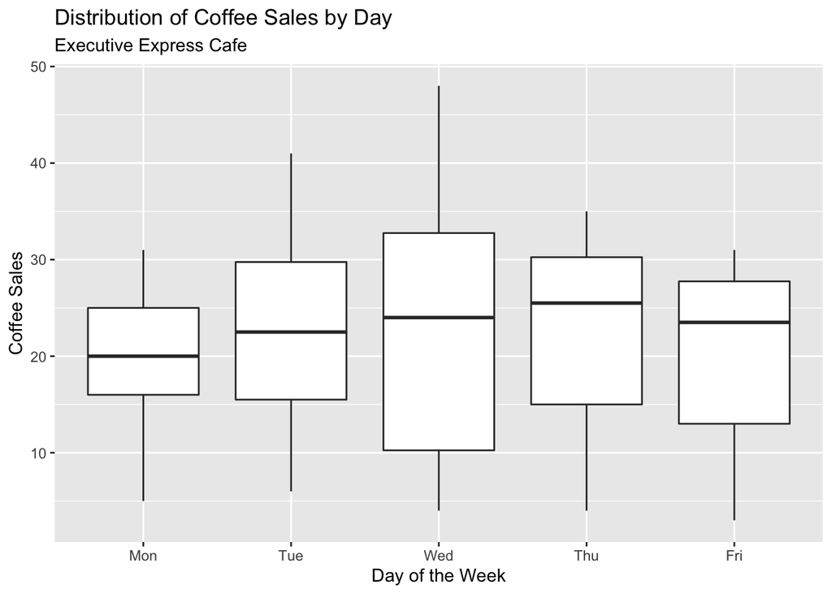

```r
cafedata_profitable$`Day of Week` = factor(cafedata_profitable$`Day of Week` , levels = c("Mon", "Tue", "Wed", "Thu", "Fri"))

ggplot(data = cafedata_profitable) +
  geom_boxplot(aes(x = `Day of Week`, y = coffees_sold)) +
  labs(x = "Day of the Week", y = "Coffee Sales", title = "Distribution of Coffee Sales by Day", subtitle = "Executive Express Cafe")
```